# Analysis 4 - Seedling Growth by Species: ABCO

Carmen Tubbesing

3/1/2017

- This is a based on some of what I learned in Analysis 2
  - for example, in terms of using VarPower
- Note: delete seedlings from PLKN and FRDS because there are not many ABCO in them
- Define function for calculating pseudo R^2

```r
pseudoR2_ABCO <- function(model, data){
  meanGrth <- mean(dfABCO$LastYearGrth.cm)
  sse <- (data$LastYearGrth.cm - predict(model))^2
  sst <- (data$LastYearGrth.cm - meanGrth)^2
  R2 <- 1 - (sum(sse)/sum(sst))
  return(R2)
}
```

#### Define function for 3D plotting

```r
plot3D <- function(data, model, Ht_range, shrub_range, Fire){
  xy <- expand.grid(Ht.cm=Ht_range, shrubarea=shrub_range, Fire = Fire)
  predmatrix <- matrix (nrow = 60, ncol = 60,  data = predict(model, newdata = data.frame(xy),interval = "prediction"))
  scatter3D(z=data$LastYearGrth.cm, x=data$Ht.cm, y=data$shrubarea, pch=18, cex=2, theta = 45, phi = 20, ticktype = "detailed",
            xlab = "Ht", ylab = "shrubarea", zlab = "growth",
            surf = list(z=predmatrix, x=Ht.cm,y=shrubarea,
                        facets = NA),
            main="fakedata")
}
```

```r
dfABCO <- df[df$Species=="ABCO" & !df$Fire %in% c("PLKN","FRDS"),]
```

- Whittling it down to the top 4 fires for ABCO leaves out only three ABCO:

```r
nrow(df[df$Species=="ABCO",])
```

```
## [1] 127
```

```r
nrow(dfABCO)
```

```
## [1] 124
```

## Use GLS function varPower

```r
varPower <- varPower(form=~Ht.cm)
```

## Start out with the best model for PIPO and test similar models

```r
dfABCO$shrubarea <- dfABCO$Ht1.2*(dfABCO$Cov1.2)
ABCO.M1 <- gls(LastYearGrth.cm ~ Ht.cm + Ht.cm*Fire + shrubarea*Ht.cm+shrubarea+Fire,
                  weights = varPower,
                  data= dfABCO, method = "ML")
pseudoR2_ABCO(ABCO.M1, dfABCO)
```

```
## [1] 0.5909073
```

```r
AIC(ABCO.M1)
```

```
## [1] 651.2974
```

```r
summary(ABCO.M1)
```

```
## Generalized least squares fit by maximum likelihood
##   Model: LastYearGrth.cm ~ Ht.cm + Ht.cm * Fire + shrubarea * Ht.cm +      shrubarea + Fire
##   Data: dfABCO
##        AIC      BIC    logLik
##   651.2974 685.1408 -313.6487
##
## Variance function:
##  Structure: Power of variance covariate
##  Formula: ~Ht.cm
##  Parameter estimates:
##     power
## 0.4147415
##
## Coefficients:
##                     Value Std.Error   t-value p-value
## (Intercept)     -2.108075  1.074279 -1.962317  0.0522
## Ht.cm            0.190187  0.024692  7.702505  0.0000
## FireCLVD         1.739597  1.363909  1.275450  0.2047
## FireSTAR         0.604987  3.311220  0.182708  0.8554
## FireWRTS         4.010458  2.412530  1.662345  0.0992
## shrubarea        0.000007  0.000012  0.593213  0.5542
## Ht.cm:FireCLVD  -0.051773  0.032812 -1.577879  0.1174
## Ht.cm:FireSTAR  -0.077512  0.056755 -1.365731  0.1747
## Ht.cm:FireWRTS  -0.110990  0.029799 -3.724623  0.0003
## Ht.cm:shrubarea  0.000000  0.000000 -0.454865  0.6501
##
##  Correlation:
##                 (Intr) Ht.cm  FrCLVD FrSTAR FrWRTS shrubr H.:FCL H.:FST
## Ht.cm           -0.891
## FireCLVD        -0.412  0.403
## FireSTAR        -0.033 -0.056  0.203
## FireWRTS        -0.228  0.172  0.247  0.148
## shrubarea       -0.578  0.503 -0.202 -0.297 -0.111
## Ht.cm:FireCLVD   0.389 -0.400 -0.789 -0.167 -0.205  0.086
## Ht.cm:FireSTAR   0.039  0.081 -0.221 -0.923 -0.183  0.339  0.221
## Ht.cm:FireWRTS   0.378 -0.327 -0.392 -0.252 -0.832  0.166  0.381  0.349
## Ht.cm:shrubarea  0.476 -0.642  0.084  0.381  0.136 -0.774 -0.065 -0.527
##                 H.:FWR
## Ht.cm
## FireCLVD
## FireSTAR
## FireWRTS
## shrubarea
## Ht.cm:FireCLVD
## Ht.cm:FireSTAR
## Ht.cm:FireWRTS
## Ht.cm:shrubarea -0.251
##
## Standardized residuals:
##         Min          Q1         Med          Q3         Max
## -2.01097165 -0.67892464 -0.09639636  0.50043227  3.13265074
##
## Residual standard error: 0.60232
## Degrees of freedom: 124 total; 114 residual
```

## Test importance of including shrubarea

```r
anova(ABCO.M1, update(ABCO.M1, . ~ . - shrubarea-shrubarea*Ht))
```

```
##                                                     Model df      AIC
## ABCO.M1                                                 1 12 651.2974
## update(ABCO.M1, . ~ . - shrubarea - shrubarea * Ht)     2 11 649.6574
##                                                          BIC    logLik
## ABCO.M1                                             685.1408 -313.6487
## update(ABCO.M1, . ~ . - shrubarea - shrubarea * Ht) 680.6805 -313.8287
##                                                       Test   L.Ratio
## ABCO.M1
## update(ABCO.M1, . ~ . - shrubarea - shrubarea * Ht) 1 vs 2 0.3600436
##                                                     p-value
## ABCO.M1
## update(ABCO.M1, . ~ . - shrubarea - shrubarea * Ht)  0.5485
```

```r
summary(ABCO.M1)
```

```
## Generalized least squares fit by maximum likelihood
##   Model: LastYearGrth.cm ~ Ht.cm + Ht.cm * Fire + shrubarea * Ht.cm +      shrubarea + Fire
##   Data: dfABCO
##        AIC      BIC    logLik
##   651.2974 685.1408 -313.6487
##
## Variance function:
##  Structure: Power of variance covariate
##  Formula: ~Ht.cm
##  Parameter estimates:
##     power
## 0.4147415
##
## Coefficients:
##                     Value Std.Error   t-value p-value
## (Intercept)     -2.108075  1.074279 -1.962317  0.0522
## Ht.cm            0.190187  0.024692  7.702505  0.0000
## FireCLVD         1.739597  1.363909  1.275450  0.2047
## FireSTAR         0.604987  3.311220  0.182708  0.8554
## FireWRTS         4.010458  2.412530  1.662345  0.0992
## shrubarea        0.000007  0.000012  0.593213  0.5542
## Ht.cm:FireCLVD  -0.051773  0.032812 -1.577879  0.1174
## Ht.cm:FireSTAR  -0.077512  0.056755 -1.365731  0.1747
## Ht.cm:FireWRTS  -0.110990  0.029799 -3.724623  0.0003
## Ht.cm:shrubarea  0.000000  0.000000 -0.454865  0.6501
##
##  Correlation:
##                 (Intr) Ht.cm  FrCLVD FrSTAR FrWRTS shrubr H.:FCL H.:FST
## Ht.cm           -0.891
## FireCLVD        -0.412  0.403
## FireSTAR        -0.033 -0.056  0.203
## FireWRTS        -0.228  0.172  0.247  0.148
## shrubarea       -0.578  0.503 -0.202 -0.297 -0.111
## Ht.cm:FireCLVD   0.389 -0.400 -0.789 -0.167 -0.205  0.086
## Ht.cm:FireSTAR   0.039  0.081 -0.221 -0.923 -0.183  0.339  0.221
## Ht.cm:FireWRTS   0.378 -0.327 -0.392 -0.252 -0.832  0.166  0.381  0.349
## Ht.cm:shrubarea  0.476 -0.642  0.084  0.381  0.136 -0.774 -0.065 -0.527
##                 H.:FWR
## Ht.cm
## FireCLVD
## FireSTAR
## FireWRTS
## shrubarea
## Ht.cm:FireCLVD
## Ht.cm:FireSTAR
## Ht.cm:FireWRTS
## Ht.cm:shrubarea -0.251
##
## Standardized residuals:
##         Min          Q1         Med          Q3         Max
## -2.01097165 -0.67892464 -0.09639636  0.50043227  3.13265074
##
## Residual standard error: 0.60232
## Degrees of freedom: 124 total; 114 residual
```

```r
pseudoR2_ABCO(update(ABCO.M1, . ~ . - shrubarea-shrubarea*Ht), dfABCO)
```

```
## [1] 0.5833561
```

```r
table <- data.frame(model=character(), AIC=numeric(), stringsAsFactors=FALSE)
```

## Try adding basal diameter

```r
ABCO.M2 <- update(ABCO.M1, .~. +BasDia.cm)
AIC(ABCO.M2)
```

```
## [1] 650.8457
```

```r
table[1,] <- c("ABCO.M1", AIC(ABCO.M1))
table <- rbind(table, c("ABCO.M2", AIC(ABCO.M2)))
table
```

```
##     model              AIC
## 1 ABCO.M1 651.297401761223
## 2 ABCO.M2  650.84565474789
```

```r
anova(ABCO.M1,ABCO.M2)
```

```
##         Model df      AIC      BIC    logLik   Test  L.Ratio p-value
## ABCO.M1     1 12 651.2974 685.1408 -313.6487
## ABCO.M2     2 13 650.8457 687.5093 -312.4228 1 vs 2 2.451747  0.1174
```

```r
summary(ABCO.M2)
```

```
## Generalized least squares fit by maximum likelihood
##   Model: LastYearGrth.cm ~ Ht.cm + Fire + shrubarea + BasDia.cm + Ht.cm:Fire +      Ht.cm:shrubarea
##   Data: dfABCO
##        AIC      BIC    logLik
##   650.8457 687.5093 -312.4228
##
## Variance function:
##  Structure: Power of variance covariate
##  Formula: ~Ht.cm
##  Parameter estimates:
##     power
## 0.4414942
##
## Coefficients:
##                      Value Std.Error   t-value p-value
## (Intercept)     -1.7395116  1.072590 -1.621786  0.1076
## Ht.cm            0.2268281  0.035795  6.336903  0.0000
## FireCLVD         1.4441117  1.340995  1.076895  0.2838
## FireSTAR        -0.0943117  3.362223 -0.028050  0.9777
## FireWRTS         2.7144329  2.470757  1.098624  0.2743
## shrubarea        0.0000089  0.000012  0.745918  0.4573
## BasDia.cm       -1.4110606  0.933778 -1.511131  0.1335
## Ht.cm:FireCLVD  -0.0418065  0.033323 -1.254571  0.2122
## Ht.cm:FireSTAR  -0.0536529  0.059517 -0.901466  0.3693
## Ht.cm:FireWRTS  -0.0827910  0.034076 -2.429629  0.0167
## Ht.cm:shrubarea -0.0000003  0.000000 -1.013145  0.3132
##
##  Correlation:
##                 (Intr) Ht.cm  FrCLVD FrSTAR FrWRTS shrubr BsD.cm H.:FCL
## Ht.cm           -0.492
## FireCLVD        -0.426  0.195
## FireSTAR        -0.047 -0.140  0.211
## FireWRTS        -0.266 -0.098  0.269  0.175
## shrubarea       -0.548  0.443 -0.209 -0.311 -0.138
## BasDia.cm       -0.157 -0.725  0.111  0.132  0.295 -0.129
## Ht.cm:FireCLVD   0.401 -0.146 -0.791 -0.181 -0.241  0.103 -0.166
## Ht.cm:FireSTAR   0.069  0.250 -0.238 -0.919 -0.241  0.364 -0.259  0.249
## Ht.cm:FireWRTS   0.402  0.166 -0.394 -0.279 -0.833  0.205 -0.496  0.405
## Ht.cm:shrubarea  0.359 -0.715  0.122  0.400  0.237 -0.753  0.429 -0.130
##                 H.:FST H.:FWR
## Ht.cm
## FireCLVD
## FireSTAR
## FireWRTS
## shrubarea
## BasDia.cm
## Ht.cm:FireCLVD
## Ht.cm:FireSTAR
## Ht.cm:FireWRTS   0.417
## Ht.cm:shrubarea -0.573 -0.407
##
## Standardized residuals:
##         Min          Q1         Med          Q3         Max
## -1.98931926 -0.64009749 -0.08485519  0.52382128  2.97714358
##
## Residual standard error: 0.5373072
## Degrees of freedom: 124 total; 113 residual
```

```r
ABCO.M3 <- update(ABCO.M1, .~. + BasDia.cm +BasDia.cm*Ht.cm)
AIC(ABCO.M3)
```

```
## [1] 652.7046
```

- So, adding basal diameter is ok but not necessary, and interaction between basal diameter and seedling height does not help

## How do the residuals looks?

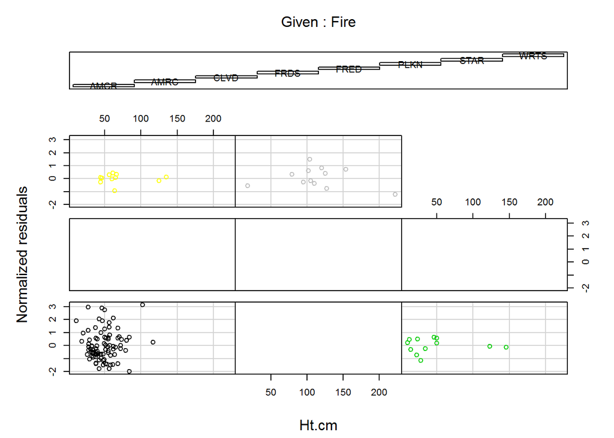

```r
E <- resid(ABCO.M1, type="normalized")
coplot(E ~ Ht.cm | Fire, data=dfABCO, ylab="Normalized residuals", col=dfABCO$Fire)
```

## Try using shrubarea with ABCO

- The models with and without shrubarea are almost identical in AIC and logLik

## Plot with predict(fakedata)

- First, fit the model again using REML

```r
ABCO.M1 <- gls(LastYearGrth.cm ~ Ht.cm + Ht.cm*Fire + shrubarea*Ht.cm+shrubarea+Fire,
                  weights = varPower,
                  data= dfABCO, method = "REML")
pseudoR2_ABCO(ABCO.M1, dfABCO)
```

```
## [1] 0.5900582
```

## Try out 3D plotting function

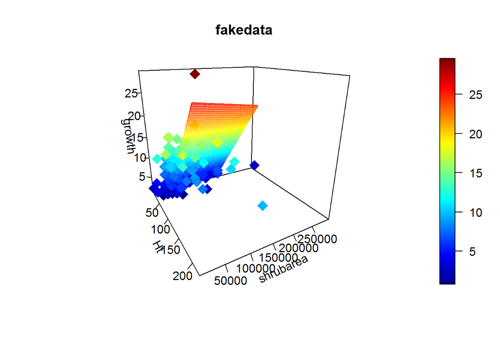

```r
data=dfABCO
model = ABCO.M1
Ht_range = seq(0,150,length.out=60)
shrub_range = seq(44375,177500,length.out=60)
Fire = "AMCR"

plot3D <- function(data, model, Ht_range, shrub_range, Fire, theta){
  xy <- expand.grid(Ht.cm=Ht_range, shrubarea=shrub_range, Fire = Fire)
  predmatrix <- matrix (nrow = 60, ncol = 60,  data = predict(model, newdata = data.frame(xy),interval = "prediction"))
  scatter3D(z=data$LastYearGrth.cm, x=data$Ht.cm, y=data$shrubarea, pch=18, cex=2, theta = theta, phi = 20, ticktype = "detailed",
            xlab = "Ht", ylab = "shrubarea", zlab = "growth",
            surf = list(z=predmatrix, x=Ht_range,y=shrub_range,
                        facets = NA),
            main="fakedata")
}

plot3D(data=dfABCO, model=ABCO.M1, Ht_range = seq(0,150,length.out=60),
shrub_range = seq(44375,177500,length.out=60),
Fire = "AMCR", theta=60)
```

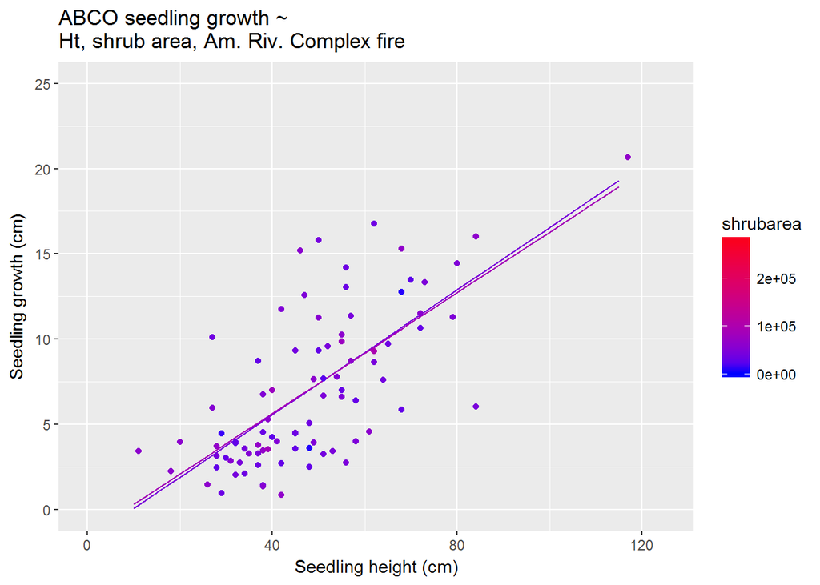

```r
library(ggplot2)
Ht.cm <- c(rep(seq(0,150,length.out=61),4))
fakedata <- as.data.frame(Ht.cm)
fakedata$shrubarea <- c(rep(c( 44375,88750,133125,177500 ),61))
fakedata$Fire <- as.factor(rep("AMCR",244))
predicted <- predict(ABCO.M1, fakedata)

pred <- as.data.frame(predicted)
pred$shrubarea <- fakedata$shrubarea
pred$Ht.cm <- fakedata$Ht.cm
pred$Fire <- fakedata$Fire

dfAMCR <- subset(dfABCO, dfABCO$Fire=="AMCR")
dfCLVD <- subset(dfABCO, dfABCO$Fire=="CLVD")
dfSTAR <- subset(dfABCO, dfABCO$Fire=="STAR")
dfFRDS <- subset(dfABCO, dfABCO$Fire=="WRTS")

plotAMCR <- ggplot(pred[pred$Ht.cm<max(dfAMCR$Ht.cm) & pred$shrubarea<=max(dfAMCR$shrubarea) & pred$shrubarea>=min(dfAMCR$shrubarea),])+
  geom_line(aes(y= predicted ,group=shrubarea,x=Ht.cm,col=shrubarea))+
  scale_color_gradient(low="blue",high="red",limits=c(0,max(dfABCO$shrubarea)))+
  labs(title = "ABCO seedling growth ~ \nHt, shrub area, Am. Riv. Complex fire")+
  ylim(0,25)+
  xlim(0,125)+
  xlab("Seedling height (cm)")+
  ylab("Seedling growth (cm)")+
  geom_point(data=dfAMCR, aes(x=Ht.cm,y=LastYearGrth.cm,col=shrubarea))

plotAMCR
```

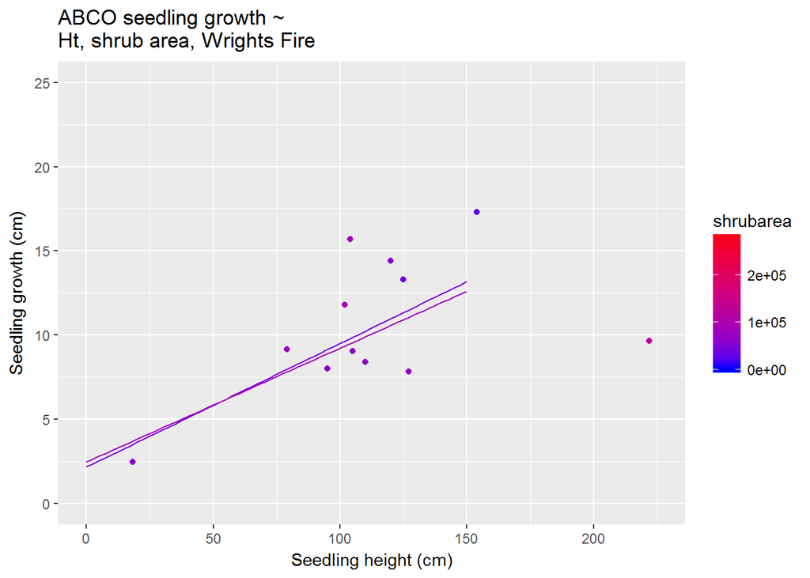

```r
fakedata$Fire <- as.factor(rep("WRTS",244))
predicted <- predict(ABCO.M1, fakedata)

pred <- as.data.frame(predicted)
pred$shrubarea <- fakedata$shrubarea
pred$Ht.cm <- fakedata$Ht.cm
pred$Fire <- fakedata$Fire

plotWRTS <- ggplot(pred[pred$Ht.cm<max(dfFRDS$Ht.cm) & pred$shrubarea<=max(dfFRDS$shrubarea) & pred$shrubarea>=min(dfFRDS$shrubarea),])+
  geom_line(aes(y= predicted ,group=shrubarea,x=Ht.cm,col=shrubarea))+
  scale_color_gradient(low="blue",high="red",limits=c(0,max(dfABCO$shrubarea)))+
  labs(title = "ABCO seedling growth ~ \nHt, shrub area, Wrights Fire")+
  ylim(0,25)+
  xlim(0,225)+
  xlab("Seedling height (cm)") +
  ylab("Seedling growth (cm)")+
  geom_point(data=dfFRDS, aes(x=Ht.cm,y=LastYearGrth.cm,col=shrubarea))

plotWRTS
```

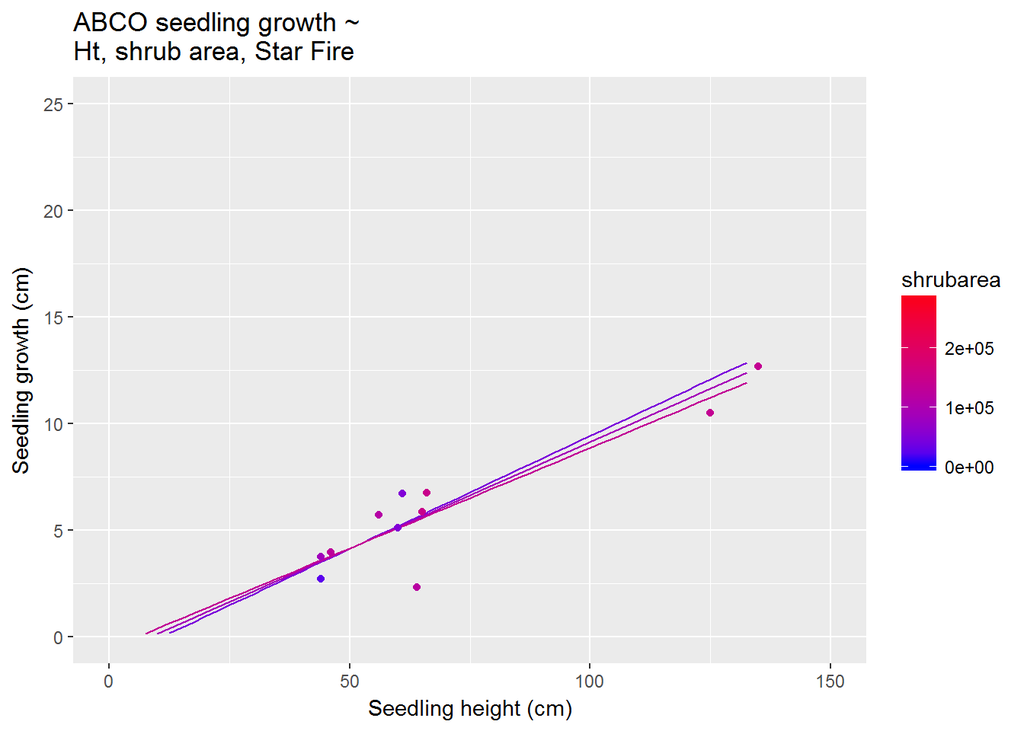

```r
fakedata$Fire <- as.factor(rep("STAR",244))
predicted <- predict(ABCO.M1, fakedata)
pred <- as.data.frame(predicted)
pred$shrubarea <- fakedata$shrubarea
pred$Ht.cm <- fakedata$Ht.cm
pred$Fire <- fakedata$Fire

plotSTAR <- ggplot(pred[pred$Ht.cm<max(dfSTAR$Ht.cm) & pred$shrubarea<=max(dfSTAR$shrubarea) & pred$shrubarea>=min(dfSTAR$shrubarea),])+
  geom_line(aes(y= predicted ,group=shrubarea,x=Ht.cm,col=shrubarea))+
  scale_color_gradient(low="blue",high="red", limits=c(0,max(dfABCO$shrubarea)))+
  labs(title = "ABCO seedling growth ~ \nHt, shrub area, Star Fire")+
  ylim(0,25)+
  xlim(0,150)+
  xlab("Seedling height (cm)") +
  ylab("Seedling growth (cm)")+
  geom_point(data=dfSTAR, aes(x=Ht.cm,y=LastYearGrth.cm,col=shrubarea))
plotSTAR
```

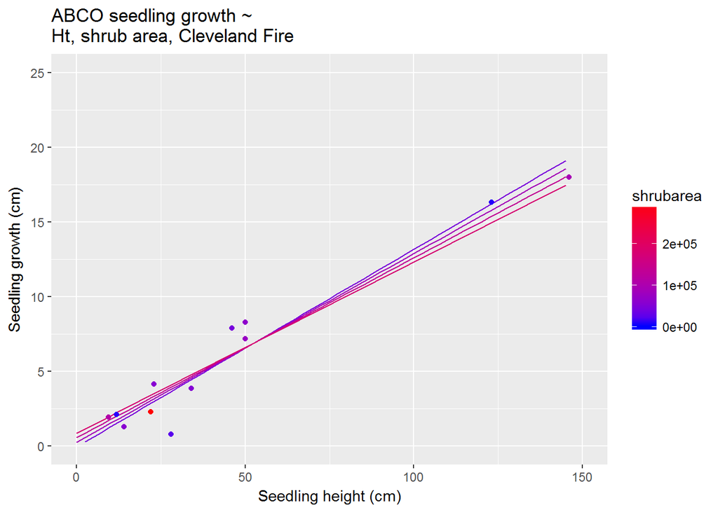

```r
fakedata$Fire <- as.factor(rep("CLVD",244))
predicted <- predict(ABCO.M1, fakedata)
pred <- as.data.frame(predicted)
pred$shrubarea <- fakedata$shrubarea
pred$Ht.cm <- fakedata$Ht.cm
pred$Fire <- fakedata$Fire

plotCLVD <- ggplot(pred[pred$Ht.cm<max(dfCLVD$Ht.cm) & pred$shrubarea<=max(dfCLVD$shrubarea) & pred$shrubarea>=min(dfCLVD$shrubarea),])+
  geom_line(aes(y= predicted ,group=shrubarea,x=Ht.cm,col=shrubarea))+
  scale_color_gradient(low="blue",high="red",limits=c(0,max(dfABCO$shrubarea)))+
  labs(title = "ABCO seedling growth ~ \nHt, shrub area, Cleveland Fire")+
  ylim(0,25)+
  xlim(0,150)+
  xlab("Seedling height (cm)") +
  ylab("Seedling growth (cm)")+
  geom_point(data=dfCLVD, aes(x=Ht.cm,y=LastYearGrth.cm,col=shrubarea))

plotCLVD
```

```r
require(gridExtra)
```

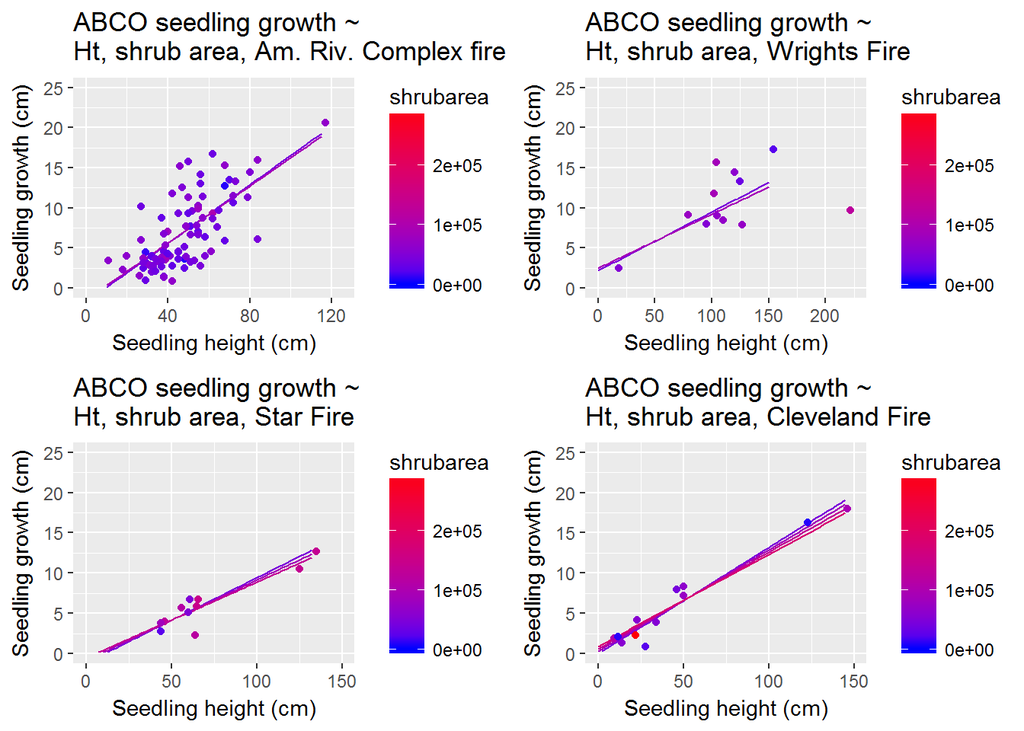

```r
all.fires <- grid.arrange(plotAMCR, plotWRTS,plotSTAR,plotCLVD,nrow=2,ncol=2 )
```

```r
all.fires
```

## What happens if you analyze AMCR data alone and remove fire effect?

- Note: I removed an outlier from the AMCR data, which switched the effect of shrubarea from positive to negative at high values of growth and seedling ht

```r
ABCO.M1 <- gls(LastYearGrth.cm ~ Ht.cm + Ht.cm*Fire + shrubarea*Ht.cm + shrubarea + Fire,
                  weights = varPower,
                  data= dfABCO, method = "REML")
AIC(ABCO.M1)
```

```
## [1] 718.7301
```

```r
AIC(update(ABCO.M1, . ~ . - Fire - Fire*Ht.cm))
```

```
## [1] 744.548
```

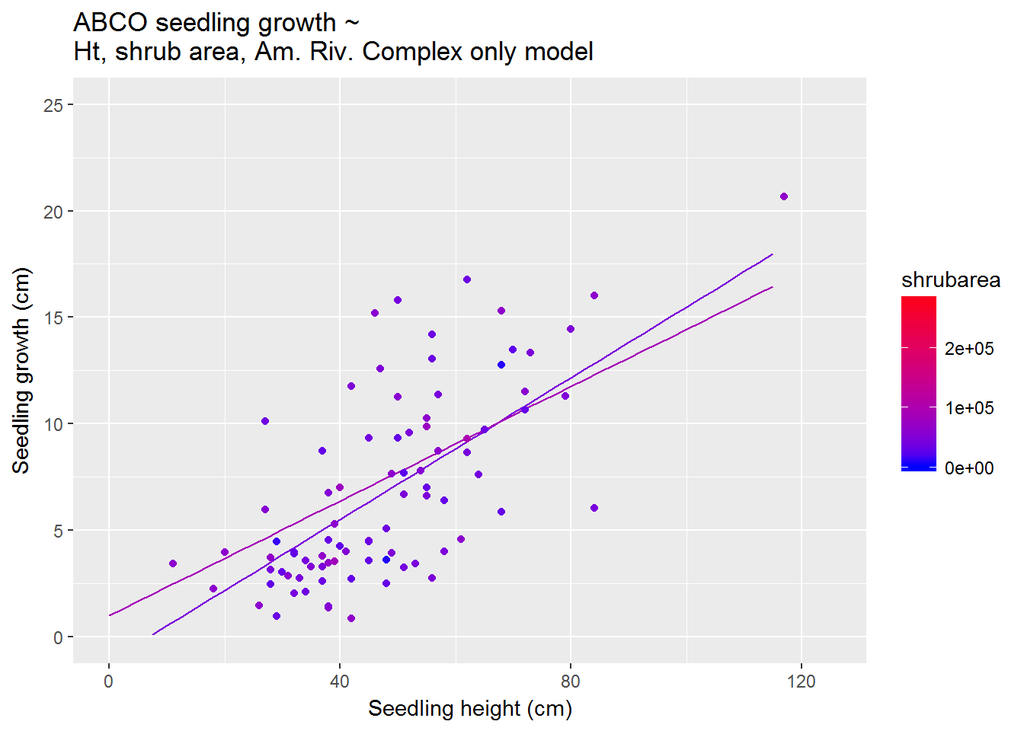

```r
ABCO.AMCR <- gls(LastYearGrth.cm ~ Ht.cm + shrubarea*Ht.cm + shrubarea,
                  weights = varPower,
                  data= dfAMCR[dfAMCR$Ht.cm<100,], method = "REML")

predicted <- predict(ABCO.AMCR, fakedata)

pred <- as.data.frame(predicted)
pred$shrubarea <- fakedata$shrubarea
pred$Ht.cm <- fakedata$Ht.cm
pred$Fire <- fakedata$Fire

plotAMCR.2 <-ggplot(pred[pred$Ht.cm<max(dfAMCR$Ht.cm) & pred$shrubarea<=max(dfAMCR$shrubarea) & pred$shrubarea>=min(dfAMCR$shrubarea),])+
  geom_line(aes(y= predicted ,group=shrubarea,x=Ht.cm,col=shrubarea))+
  scale_color_gradient(low="blue",high="red",limits=c(0,max(dfABCO$shrubarea)))+
  labs(title = "ABCO seedling growth ~ \nHt, shrub area, Am. Riv. Complex only model")+
  ylim(0,25)+
  xlim(0,125)+
  xlab("Seedling height (cm)")+
  ylab("Seedling growth (cm)")+
  geom_point(data=dfAMCR, aes(x=Ht.cm,y=LastYearGrth.cm,col=shrubarea))
plotAMCR.2
```

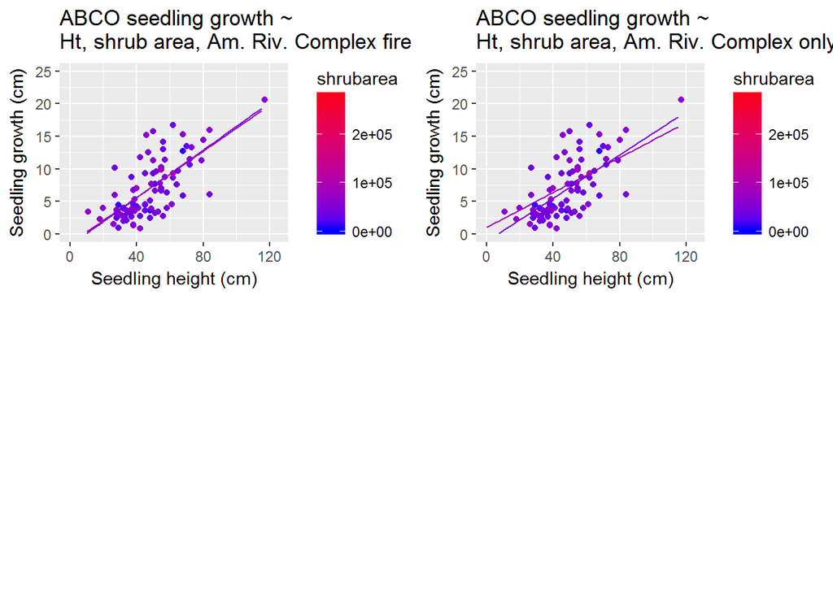

```r
AMCR.compare <- grid.arrange(plotAMCR,plotAMCR.2,nrow=2,ncol=2)
```

- Answer: It’s important.

## Graph effect of change in basal diameter

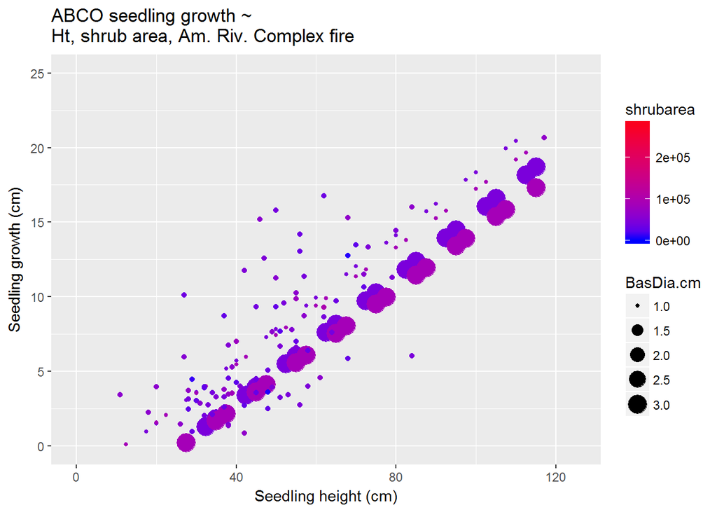

```r
ABCO.M2 <- gls(LastYearGrth.cm ~ Ht.cm + Ht.cm*Fire + shrubarea*Ht.cm + shrubarea + Fire + BasDia.cm,
                  weights = varPower,
                  data= dfABCO, method = "REML")
Ht.cm <- c(rep(seq(0,150,length.out=61),4))
fakedata <- as.data.frame(Ht.cm)
fakedata$shrubarea <- c(rep(c( 44375,88750,133125,177500 ),61))
fakedata$Fire <- as.factor(rep("AMCR",244))
fakedata$BasDia.cm <- c(rep(1,122),rep(3,122))
predicted <- predict(ABCO.M2, fakedata)

pred <- as.data.frame(predicted)
pred$shrubarea <- fakedata$shrubarea
pred$Ht.cm <- fakedata$Ht.cm
pred$Fire <- fakedata$Fire
pred$BasDia.cm <- fakedata$BasDia.cm

plotAMCR <- ggplot(pred[pred$Ht.cm<max(dfAMCR$Ht.cm) & pred$shrubarea<=max(dfAMCR$shrubarea) & pred$shrubarea>=min(dfAMCR$shrubarea),])+
  geom_point(aes(y= predicted ,group=shrubarea,x=Ht.cm,col=shrubarea,size=BasDia.cm))+
  scale_color_gradient(low="blue",high="red",limits=c(0,max(dfABCO$shrubarea)))+
  labs(title = "ABCO seedling growth ~ \nHt, shrub area, Am. Riv. Complex fire")+
  ylim(0,25)+
  xlim(0,125)+
  xlab("Seedling height (cm)")+
  ylab("Seedling growth (cm)")+
  geom_point(data=dfAMCR, aes(x=Ht.cm,y=LastYearGrth.cm,col=shrubarea))

plotAMCR
```

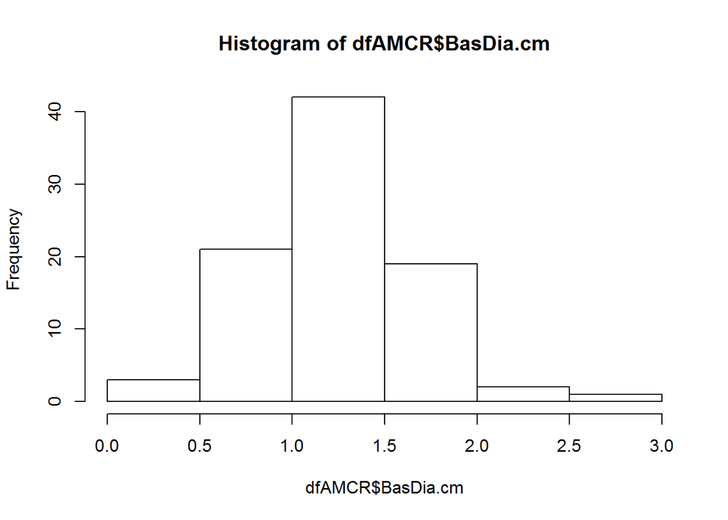

```r
hist(dfAMCR$BasDia.cm)
```

- There is a negative relationship between basal diameter and vertical seedling growth - how will I incorporate that into SORTIE given that I was hoping to consistently model diameter allometrically with height? Perhaps this summer when I remeasure diameter I can relate basal diameter growth with height growth

## Try including DIFN

```r
baseline <- gls(LastYearGrth.cm ~ Ht.cm + Ht.cm*Fire + shrubarea*Ht.cm + shrubarea + Fire,
                  weights = varPower,
                  data= dfABCO[!is.na(dfABCO$DIFN.53),], method = "ML")
M.DIFN <- gls(LastYearGrth.cm ~ Ht.cm + Ht.cm*Fire + shrubarea*Ht.cm + shrubarea + Fire + DIFN.53,
                  weights = varPower,
                  data= dfABCO[!is.na(dfABCO$DIFN.53),], method = "ML")

AIC(baseline)
```

```
## [1] 565.6322
```

```r
AIC(baseline) - AIC(M.DIFN)
```

```
## [1] -0.4057716
```

```r
AIC(baseline) - AIC(update(M.DIFN, . ~ . - DIFN.53 + DIFN.all))
```

```
## [1] -0.2628403
```

```r
AIC(baseline) - AIC(update(M.DIFN, . ~ . - DIFN.53 + DIFN.all + DIFN.all*Ht.cm))
```

```
## [1] -0.05977533
```

```r
AIC(baseline) - AIC(update(M.DIFN, . ~ . - shrubarea-shrubarea*Ht.cm))
```

```
## [1] 0.9764606
```

```r
AIC(baseline) - AIC(update(M.DIFN, . ~ . - shrubarea -shrubarea*Ht.cm + DIFN.53*Ht.cm))
```

```
## [1] 4.817671
```

```r
AIC(baseline) - AIC(update(M.DIFN, . ~ . + DIFN.53*Ht.cm))
```

```
## [1] 0.9267839
```

#### it looks like the model without shrubarea and with DIFN.53 is slightly better. Check out its R^2 and coefficients

```r
M.DIFN <- update(M.DIFN, . ~ . - shrubarea -shrubarea*Ht.cm + DIFN.53*Ht.cm)
dfABCODIFN <- dfABCO[!is.na(dfABCO$DIFN.53),]
pseudoR2_ABCO(M.DIFN, dfABCODIFN)
```

```
## [1] 0.5694046
```

```r
pseudoR2_ABCO(baseline, dfABCODIFN)
```

```
## [1] 0.548985
```

```r
summary(M.DIFN)
```

```
## Generalized least squares fit by maximum likelihood
##   Model: LastYearGrth.cm ~ Fire + DIFN.53 + Ht.cm + Ht.cm:Fire + Ht.cm:DIFN.53
##   Data: dfABCO[!is.na(dfABCO$DIFN.53), ]
##        AIC      BIC    logLik
##   560.8145 593.1107 -268.4073
##
## Variance function:
##  Structure: Power of variance covariate
##  Formula: ~Ht.cm
##  Parameter estimates:
##     power
## 0.2234894
##
## Coefficients:
##                    Value Std.Error   t-value p-value
## (Intercept)     0.860305 1.2315819  0.698536  0.4865
## FireCLVD        2.280156 1.6816930  1.355869  0.1782
## FireSTAR        0.082605 3.0312923  0.027251  0.9783
## FireWRTS        2.344004 2.8975874  0.808950  0.4205
## DIFN.53        -7.564007 2.9859403 -2.533208  0.0129
## Ht.cm           0.137339 0.0243552  5.639019  0.0000
## FireCLVD:Ht.cm -0.052711 0.0335305 -1.572034  0.1191
## FireSTAR:Ht.cm -0.059781 0.0442204 -1.351883  0.1795
## FireWRTS:Ht.cm -0.091472 0.0341936 -2.675121  0.0087
## DIFN.53:Ht.cm   0.102676 0.0431890  2.377366  0.0194
##
##  Correlation:
##                (Intr) FrCLVD FrSTAR FrWRTS DIFN.53 Ht.cm  FCLVD: FSTAR:
## FireCLVD       -0.329
## FireSTAR       -0.282  0.193
## FireWRTS       -0.222  0.228  0.099
## DIFN.53        -0.582 -0.262  0.008 -0.089
## Ht.cm          -0.893  0.407  0.332  0.230  0.334
## FireCLVD:Ht.cm  0.350 -0.822 -0.172 -0.242  0.226  -0.437
## FireSTAR:Ht.cm  0.402 -0.265 -0.908 -0.138 -0.026  -0.509  0.271
## FireWRTS:Ht.cm  0.366 -0.401 -0.171 -0.867  0.183  -0.446  0.465  0.270
## DIFN.53:Ht.cm   0.536  0.228 -0.090  0.118 -0.863  -0.457 -0.273  0.132
##                FWRTS:
## FireCLVD
## FireSTAR
## FireWRTS
## DIFN.53
## Ht.cm
## FireCLVD:Ht.cm
## FireSTAR:Ht.cm
## FireWRTS:Ht.cm
## DIFN.53:Ht.cm  -0.228
##
## Standardized residuals:
##         Min          Q1         Med          Q3         Max
## -2.15257570 -0.64780931 -0.08888862  0.59391222  3.10307676
##
## Residual standard error: 1.195012
## Degrees of freedom: 109 total; 99 residual
```

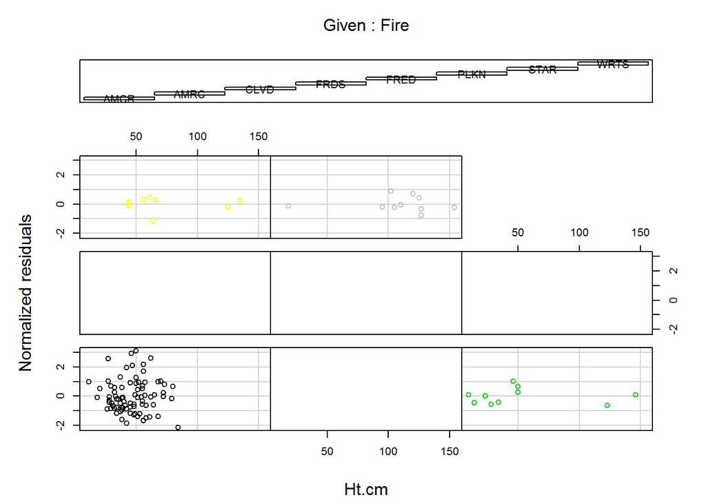

```r
E <- resid(M.DIFN, type="normalized")
coplot(E ~ Ht.cm | Fire, data=dfABCODIFN, ylab="Normalized residuals", col=dfABCODIFN$Fire)
```

## Relationships between shrubarea and DIFN

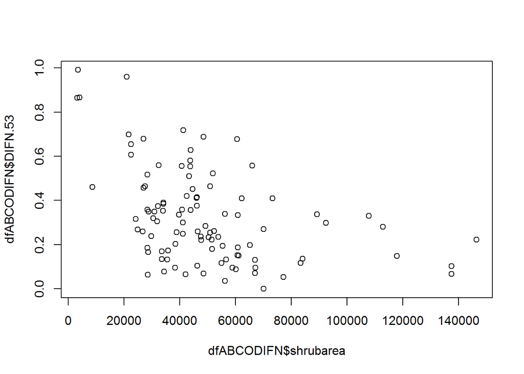

```r
plot(dfABCODIFN$shrubarea,dfABCODIFN$DIFN.53)
```

```r
library(mgcv)
```

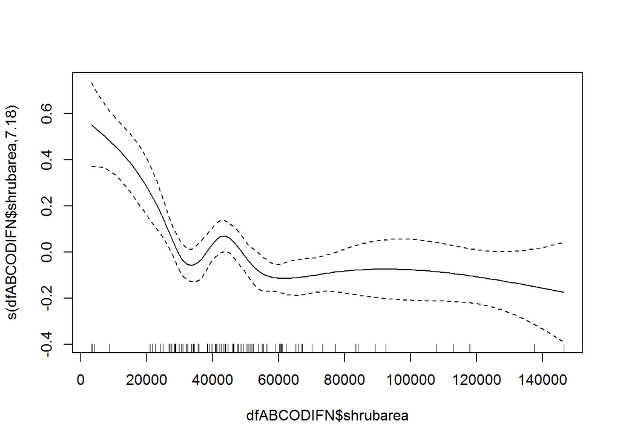

```r
M1 <- gam(dfABCODIFN$DIFN.53 ~ s(dfABCODIFN$shrubarea, fx=F, k=-1, bs="cr"))
plot(M1, se=TRUE)
```

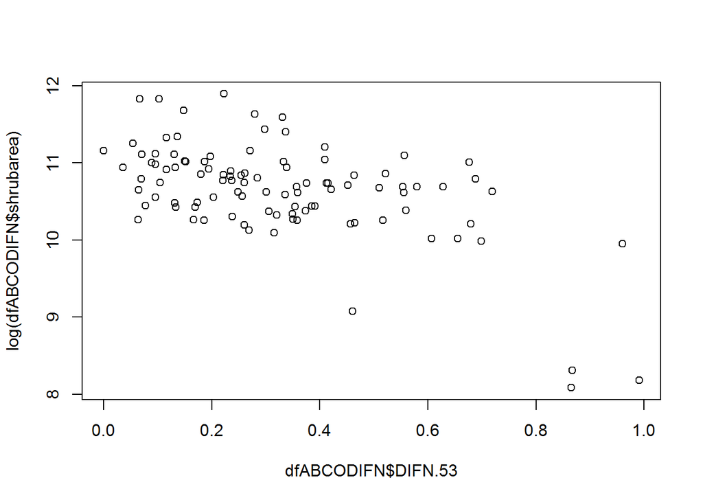

```r
plot(dfABCODIFN$DIFN.53,log(dfABCODIFN$shrubarea))
```

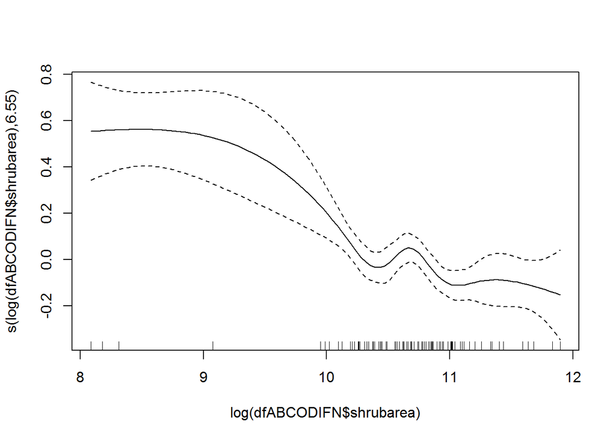

```r
M2 <- gam(dfABCODIFN$DIFN.53 ~ s(log(dfABCODIFN$shrubarea), fx=F, k=-1, bs="cr"))
plot(M2, se=TRUE, add=T)
```